# Project 1: Wrangling, Exploration, Visualization

#### Wrangling

```r
library(knitr)
cleanJoinedSet = joinedSet %>% filter(complete.cases(joinedSet))  # to remove rows containing NA and clean up dataset


cleanJoinedSet %>% summarize(mean = mean(year), standardDeviation = sd(year),
    variance = var(year), maximum = max(year), distinctObservations = n_distinct(year)) %>%
    kable(caption = "Year")  # for year
```

Year

| mean | standardDeviation | variance | maximum | distinctObservations |
| --- | --- | --- | --- | --- |
| 1995.33 | 14.08598 | 198.4147 | 2016 | 49 |

```r
cleanJoinedSet %>% group_by(percentile) %>% summarize(count = n())  # for percentile
```

```
## # A tibble: 3 x 2
##   percentile count
##   <chr>      <int>
## 1 10th        2820
## 2 50th        2820
## 3 90th        2820
```

```r
cleanJoinedSet %>% group_by(race) %>% summarize(mean = mean(income_family),
    standardDeviation = sd(income_family), variance = var(income_family),
    maximum = max(income_family), distinctObservations = n_distinct(income_family)) %>%
    kable(caption = "Family Income")  # for income_family
```

Family Income

| race | mean | standardDeviation | variance | maximum | distinctObservations |
| --- | --- | --- | --- | --- | --- |
| All Races | 73344.88 | 55233.86 | 3050779033 | 182826 | 146 |
| Asian Alone | 80703.55 | 64193.99 | 4120868137 | 182826 | 44 |
| Asian Alone or in Combination | 80703.55 | 64193.99 | 4120868137 | 182826 | 44 |
| Black Alone | 73344.88 | 55233.86 | 3050779033 | 182826 | 146 |
| Black Alone or in Combination | 80703.55 | 64193.99 | 4120868137 | 182826 | 44 |
| Hispanic | 74241.92 | 56284.47 | 3167941104 | 182826 | 134 |
| White Alone | 73344.88 | 55233.86 | 3050779033 | 182826 | 146 |
| White, Not Hispanic | 74241.92 | 56284.47 | 3167941104 | 182826 | 134 |

```r
cleanJoinedSet %>% group_by(race) %>% summarize(count = n()) %>%
    arrange(count)  # for race
```

```
## # A tibble: 8 x 2
##   race                          count
##   <chr>                         <int>
## 1 Asian Alone                     450
## 2 Asian Alone or in Combination   450
## 3 Black Alone or in Combination   450
## 4 Hispanic                       1350
## 5 White, Not Hispanic            1350
## 6 All Races                      1470
## 7 Black Alone                    1470
## 8 White Alone                    1470
```

```r
cleanJoinedSet %>% group_by(dollar_type) %>% summarize(count = n())  # for dollar_type
```

```
## # A tibble: 2 x 2
##   dollar_type     count
##   <chr>           <int>
## 1 2019 Dollars     4230
## 2 Current Dollars  4230
```

```r
cleanJoinedSet %>% group_by(race, percentile) %>% summarize(mean = mean(number),
    standardDeviation = sd(number), variance = var(number), maximum = max(number),
    distinctObservations = n_distinct(number)) %>% kable(caption = "Number of Households")  # for number
```

Number of Households

| race | percentile | mean | standardDeviation | variance | maximum | distinctObservations |
| --- | --- | --- | --- | --- | --- | --- |
| All Races | 10th | 96287122 | 19114140.3 | 3.653504e+14 | 126224000 | 49 |
| All Races | 50th | 96287122 | 19114140.3 | 3.653504e+14 | 126224000 | 49 |
| All Races | 90th | 96287122 | 19114140.3 | 3.653504e+14 | 126224000 | 49 |
| Asian Alone | 10th | 5152633 | 864270.4 | 7.469633e+11 | 6750000 | 30 |
| Asian Alone | 50th | 5152633 | 864270.4 | 7.469633e+11 | 6750000 | 30 |
| Asian Alone | 90th | 5152633 | 864270.4 | 7.469633e+11 | 6750000 | 30 |
| Asian Alone or in Combination | 10th | 5152633 | 864270.4 | 7.469633e+11 | 6750000 | 30 |
| Asian Alone or in Combination | 50th | 5152633 | 864270.4 | 7.469633e+11 | 6750000 | 30 |
| Asian Alone or in Combination | 90th | 5152633 | 864270.4 | 7.469633e+11 | 6750000 | 30 |
| Black Alone | 10th | 11252347 | 3170802.2 | 1.005399e+13 | 16733000 | 49 |
| Black Alone | 50th | 11252347 | 3170802.2 | 1.005399e+13 | 16733000 | 49 |
| Black Alone | 90th | 11252347 | 3170802.2 | 1.005399e+13 | 16733000 | 49 |
| Black Alone or in Combination | 10th | 15575400 | 1239342.1 | 1.535969e+12 | 17505000 | 15 |
| Black Alone or in Combination | 50th | 15575400 | 1239342.1 | 1.535969e+12 | 17505000 | 15 |
| Black Alone or in Combination | 90th | 15575400 | 1239342.1 | 1.535969e+12 | 17505000 | 15 |
| Hispanic | 10th | 8547311 | 4499716.1 | 2.024744e+13 | 16915000 | 45 |
| Hispanic | 50th | 8547311 | 4499716.1 | 2.024744e+13 | 16915000 | 45 |
| Hispanic | 90th | 8547311 | 4499716.1 | 2.024744e+13 | 16915000 | 45 |
| White Alone | 10th | 80984490 | 13230873.5 | 1.750560e+14 | 99400000 | 49 |
| White Alone | 50th | 80984490 | 13230873.5 | 1.750560e+14 | 99400000 | 49 |
| White Alone | 90th | 80984490 | 13230873.5 | 1.750560e+14 | 99400000 | 49 |
| White, Not Hispanic | 10th | 75219022 | 7736676.5 | 5.985616e+13 | 84445000 | 45 |
| White, Not Hispanic | 50th | 75219022 | 7736676.5 | 5.985616e+13 | 84445000 | 45 |
| White, Not Hispanic | 90th | 75219022 | 7736676.5 | 5.985616e+13 | 84445000 | 45 |

```r
cleanJoinedSet %>% group_by(income_quintile) %>% summarize(count = n())  # for income_quintile
```

```
## # A tibble: 5 x 2
##   income_quintile count
##   <chr>           <int>
## 1 Fourth           1692
## 2 Lowest           1692
## 3 Second           1692
## 4 Third            1692
## 5 Top 5%           1692
```

```r
se = function(x) sd(x)/sqrt(n())  #function for standard error

cleanJoinedSet %>% filter(str_detect(dollar_type, "2019")) %>%
    group_by(income_quintile) %>% summarize(mean = mean(income_dollars),
    standardDeviation = sd(income_dollars), variance = var(income_dollars),
    maximum = max(income_dollars), standardError = se(income_dollars),
    distinctObservations = n_distinct(income_dollars)) %>% pivot_longer(-1,
    names_to = "Summary Statistics", values_to = "Value") %>%
    kable(caption = "Income Limit")  # for income_dollars, filter is so that income limit is in contemporary currency
```

Income Limit

| income_quintile | Summary Statistics | Value |
| --- | --- | --- |
| Fourth | mean | 1.031960e+05 |
| Fourth | standardDeviation | 2.599115e+04 |
| Fourth | variance | 6.755398e+08 |
| Fourth | maximum | 1.734140e+05 |
| Fourth | standardError | 8.935941e+02 |
| Fourth | distinctObservations | 2.800000e+02 |
| Lowest | mean | 2.225057e+04 |
| Lowest | standardDeviation | 5.702831e+03 |
| Lowest | variance | 3.252229e+07 |
| Lowest | maximum | 3.376400e+04 |
| Lowest | standardError | 1.960674e+02 |
| Lowest | distinctObservations | 2.730000e+02 |
| Second | mean | 4.217228e+04 |
| Second | standardDeviation | 1.084295e+04 |
| Second | variance | 1.175695e+08 |
| Second | maximum | 6.937100e+04 |
| Second | standardError | 3.727882e+02 |
| Second | distinctObservations | 2.770000e+02 |
| Third | mean | 6.626328e+04 |
| Third | standardDeviation | 1.662051e+04 |
| Third | variance | 2.762412e+08 |
| Third | maximum | 1.069360e+05 |
| Third | standardError | 5.714248e+02 |
| Third | distinctObservations | 2.800000e+02 |
| Top 5% | mean | 1.785861e+05 |
| Top 5% | standardDeviation | 4.856079e+04 |
| Top 5% | variance | 2.358150e+09 |
| Top 5% | maximum | 3.022580e+05 |
| Top 5% | standardError | 1.669554e+03 |
| Top 5% | distinctObservations | 2.820000e+02 |

```r
glimpse(cleanJoinedSet %>% select(income_family, households = number) %>%
    mutate(standardErrorIncomeFamily = se(income_family)))  # to show how to rename a column using select and how to add a column using mutate
```

```
## Rows: 8,460
## Columns: 3
## $ income_family             <dbl> 16201.76, 16201.76, 16201.76, 16201.76, 162…
## $ households                <dbl> 60813000, 60813000, 60813000, 60813000, 608…
## $ standardErrorIncomeFamily <dbl> 621.0253, 621.0253, 621.0253, 621.0253, 621…
```

*NA values were removed from joinedSet and the now-clean dataset was saved as cleanJoinedSet. Five summary statistics (mean, standard deviation, variance, maximum value, and distinct observations) were taken for each numerical variable in cleanJoinedSet: year, income_family, number, and income_dollars. income_dollars also had an extra summary statistic taken: standard error. The categorical variables (percentile, race, dollar_type, income_quantile) were counted in a table.*

*One interesting finding is that the mean number of households per race over the past few decades is lower for Asians at 5,152,633 than any other racial group. This could be indicative of demographics in the United States: that those who are Asian alone are heavily outnumbered in America among the racial groups included in the dataset.*

#### Visualizing

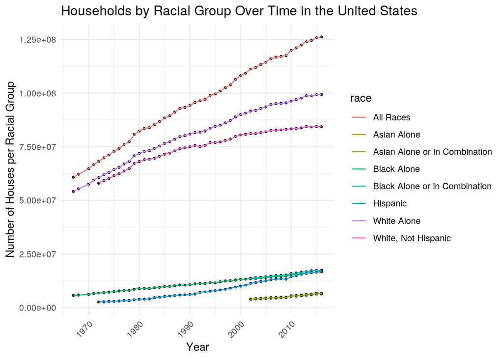

```r
ggplot(data = cleanJoinedSet, aes(x = year, y = number)) + geom_point(size = 0.5) +
    geom_line(aes(color = race)) + theme_minimal() + xlab("Year") +
    ylab("Number of Houses per Racial Group") + ggtitle("Households by Racial Group Over Time in the United States") +
    theme(axis.text.x = element_text(angle = 45, hjust = 1))
```

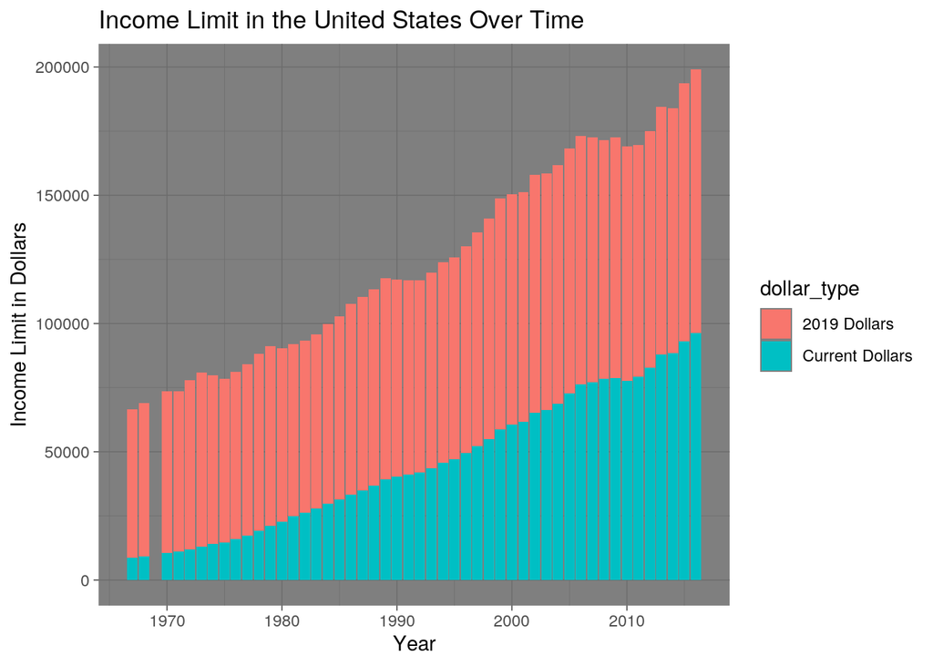

```r
ggplot(cleanJoinedSet, aes(x = year, fill = dollar_type)) + geom_bar(aes(y = income_dollars,
    position = "fill"), stat = "summary", fun = mean) + xlab("Year") +
    ylab("Income Limit in Dollars") + ggtitle("Income Limit in the United States Over Time") +
    theme(axis.text.x = element_text(angle = 45, hjust = 1)) +
    theme_dark()
```

*The plot shows variable income_dollars vs variable year. As the years pass, the income limit for each quintile has also risen.*

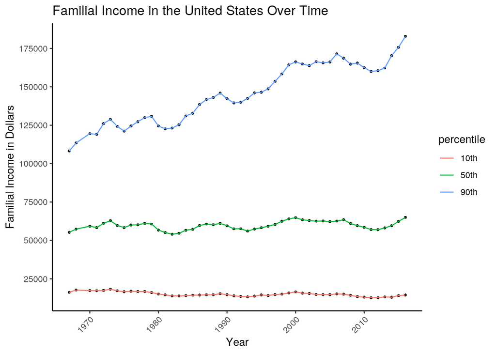

```r
ggplot(data = cleanJoinedSet, aes(x = year, y = income_family)) +
    geom_point(size = 0.5) + theme_classic() + xlab("Year") +
    ylab("Familial Income in Dollars") + ggtitle("Familial Income in the United States Over Time") +
    theme(axis.text.x = element_text(angle = 45, hjust = 1)) +
    scale_y_continuous(breaks = seq(0, 2e+05, 25000)) + geom_line(aes(color = percentile))
```

*The plot shows variable income_family vs variable year. While familial income has increased overall throughout the years for the 90th percentile, the 50th and 10th percentiles show very little change. This could be indicative of growing wealth inequality between average or poor American citizens and the affluent.*